# Workshop 4 Worksheet

##### Task 6: Multiple regression model

**On your own**

You should now have all the information needed to fit and interpret a multiple logistic regression model that can give us an estimate of how “age” is associated with “social trust” in a British population in 2010-2011, when adjusting for “sex”.

**Tip: plot re logistic coefficients on a probability scale**

One useful reporting trick - especially when we also have categorical/indicator predictors - is to plot the coefficients on a *probability* scale. If you recall, this means that we re-convert the “log-odds” and the “odds ratio” coefficients to probabilities, which has some nice properties - it runs from $0-1$, just like proportions - allowing for easier interpretations.

We can do that by requesting *[Inferential plots >] Conditional estimates plots* under the plots drop-down option set, which will result in the following output:

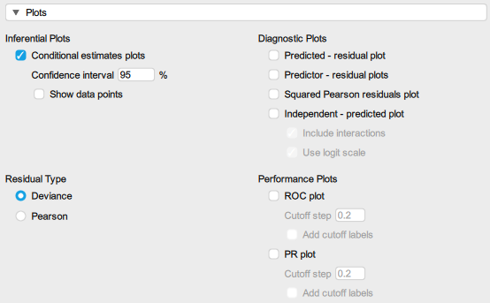

JASP Analysis panel

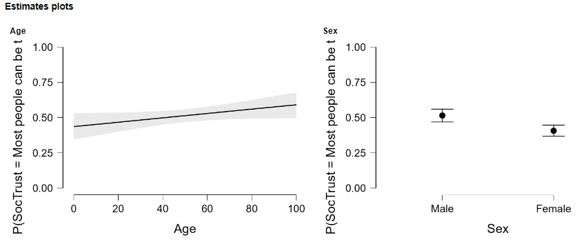

JASP Results panel

Logistic regression: Conditional estimates plots

#### Modelling `PeopTrs3`

**Important**

To model this variable, we need to recode the values of `PeopTrs3` manually so it only has 0 and 1 values. That means that we need to make a decision on how to group together the individual values of the $1\ldots5$ valid scale on which the variable was measured. We could recode all values from $1-3$ into $0$ and $4-5$ into $1$, or could have $1-2$ as $0$ and $3-5$ as $1$. Run some univariate descriptive statistics and some bivariate visualisations to check the empirical distribution of the variable; think about the logic underpinning the variable and survey question; then you can make a decision that you can defend.

In practical data analysis you will often encounter situations when you will want to recode categorical variables into fewer categories than the original scale. Such a situation may emerge in the course of an *assignment task* in which the variable chosen as *dependent variable* in a planned regression model is multi-categorical (multinomial). There are special statistical models for such dependent variables, however, in this module we are not covering these more advanced methods. Instead, you will want to transform the variables - if logically, conceptually or theoretically possible - into binary/binomial/dichotomous variables (i.e. variables with only two categories).

Such transformations are easy to implement in JASP, and the procedure amounts to manually re-coding the values of the categories by giving several categories the same values. I demonstrate how to recode multinomial variables in the two videos below:

[video not shown]

To follow the example transformations in the demo videos, you can use the `data_transformation` dataset available to download from the module website’s Data page.

##### Task 1: Summarise the variables

##### Task 2: Univariate descriptive analysis

##### Task 3: Data transformations

##### Task 4: Bivariate descriptive analysis

##### Task 5: Simple regression model

##### Task 6: Multiple regression model

##### Task 7: Interpretation

### Exercise 4.1.2. Citizenship Survey, 2010-2011

**Exercise 4.1.2. Dataset**

Download the `gb-cs10-trust.sav` dataset and open it in JASP. The dataset is also available on the Data page.

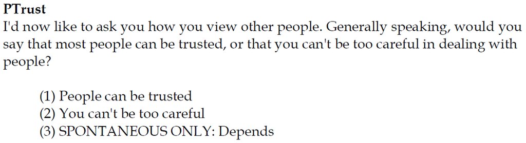

Figure 11: Social Trust operationalised in the 2010-2011 Citizenship Survey

##### Task 1: Summarise the variables

##### Task 2: Univariate descriptive analysis

##### Task 3: Data transformations

##### Task 4: Bivariate descriptive analysis

##### Task 5: Simple regression model

##### Task 6: Multiple regression model

##### Task 7: Interpretation

## Exercise 4.2: Do young people (under-24s) have lower *social trust* in post-pandemic Britain?

You will use the following three datasets, in turn, to model social phenomena in “post-pandemic” Britain:

- Community Life Survey 2023-24 (`gb-cls23-trust_nm.sav`)
- British Social Attitudes Survey 2024 (`gb-bsa24-trust.sav`)
- British Social Attitudes Survey 2023 (`gb-bsa23-trust.sav`)

### Exercise 4.2.1. Community Life Survey, 2023-2024

**Exercise 4.2.1 Dataset**

Download the `gb-cls23-trust_nm.sav` dataset and open it in JASP. The dataset is also available on the Data page.

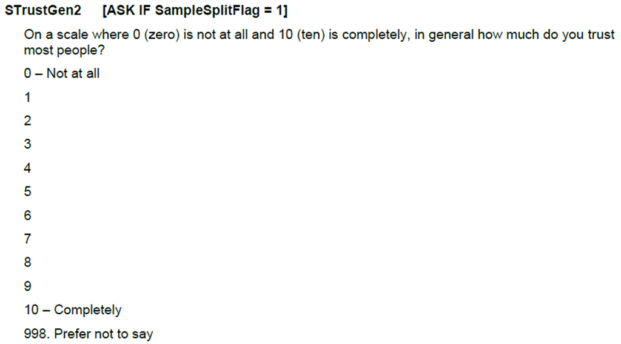

Figure 12: “Social trust” operationalised in the 2023-2024 Community Life Survey

Read the research question carefully and identify what it *does* and *doesn’t* tell you about the variables, data selection and modelling methods that are needed to address the question as directly as possible. Consider the following questions in particular:

- Which “age” variable would you choose if you had more than one option available, and what kind of transformation may be useful in order to answer your research question?
- Do you need to transform your outcome/dependent variable, or can it be modelled as it is? (You may have different option here!)
- If you wanted to fit a binary logistic regression model, how would you need to transform the outcome variable, if at all?
- Can you fit two different types of regression models and compare the results?
- Do you have any other eligible “control” variables at your disposal in the dataset? If so, what would be the benefit of including them in the model?

##### Task 1: Summarise the variables

##### Task 2: Univariate descriptive analysis

##### Task 3: Data transformations

##### Task 4: Bivariate descriptive analysis

##### Task 5: Simple regression model

##### Task 6: Multiple regression model

##### Task 7: Interpretation

### Exercise 4.2.2. British Social Attitudes Survey, 2023

**Exercise 4.2.2 Dataset**

Download the `gb-bsa23-trust.sav` dataset and open it in JASP. The dataset is also available on the Data page.

The “social trust” variable in this dataset poses similar (but somewhat simpler) data transformation challenges to those encountered with the 2010 BSA (Self-completion) “social trust” variable.

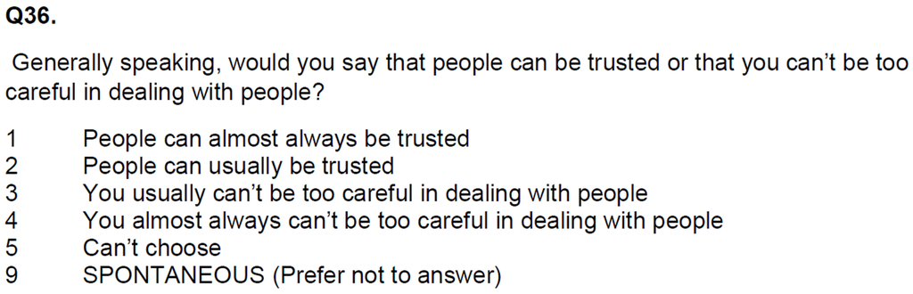

Figure 13: “Social trust” operationalised in the 2023 BSA

##### Task 1: Summarise the variables

##### Task 2: Univariate descriptive analysis

##### Task 3: Data transformations

##### Task 4: Bivariate descriptive analysis

##### Task 5: Simple regression model

##### Task 6: Multiple regression model

##### Task 7: Interpretation

### Exercise 4.2.3. British Social Attitudes Survey, 2024

**Exercise 4.2.3 Dataset**

Download the `gb-bsa24-trust.sav` dataset and open it in JASP. The dataset is also available on the Data page.

The “social trust” variable in this dataset is similar to the one encountered in the 2023-2024 *Community Life Survey.*

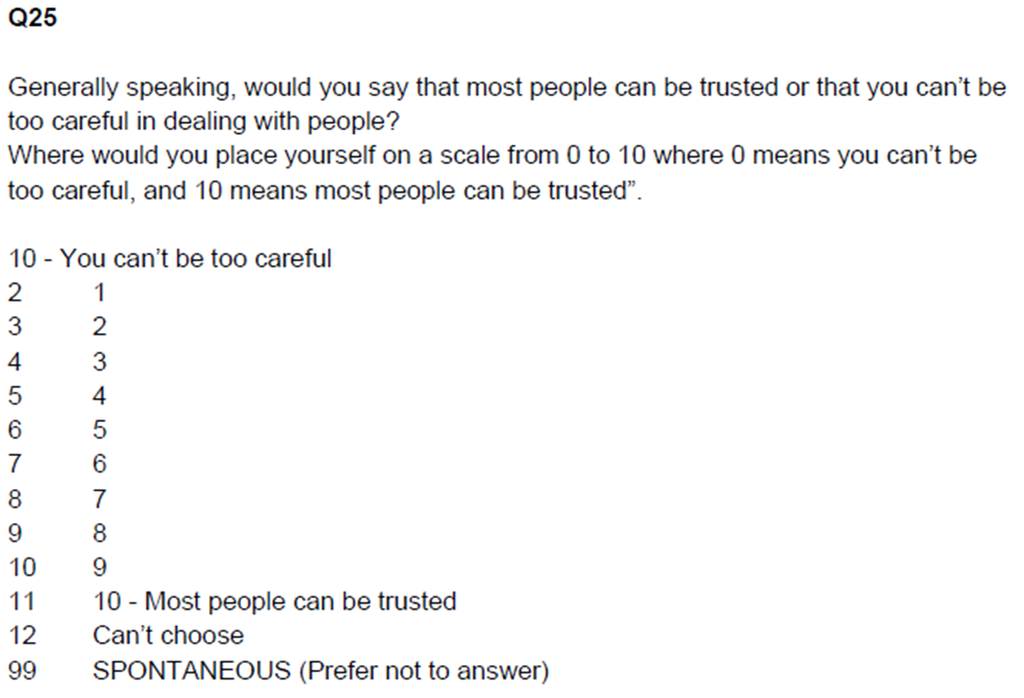

Figure 14: “Social trust” operationalised in the 2024 BSA

##### Task 1: Summarise the variables

##### Task 2: Univariate descriptive analysis

##### Task 3: Data transformations

##### Task 4: Bivariate descriptive analysis

##### Task 5: Simple regression model

##### Task 6: Multiple regression model

##### Task 7: Interpretation

## Exercise 4.3: Which of the assignment research questions could be addressed using a logistic regression model?

Let’s look again at the assignment research questions. Some of these questions imply a *dependent* variable which is measured as a *numeric scale* or at least a long-ish (e.g. 7-point +) *ordinal scale* in one of the surveys we will use for the assignment (ESS10, WVS7, EVS2017). Other questions imply *dependent* variables that are more strictly *categorical*, and as such, we cannot model them using linear regression. For those, we may be able to apply a logistic regression model.

If your chosen outcome variable is categorical with more than two categories but fewer than at least seven, you will have to dichotomise it in order to use it as a dependent variable in a logistic regression. While there are specific modelling methods for “multinomial” type outcome variables, we are not covering them on this module.

In this exercise, explore the assignment dataset using the Variable search function on the website to identify any available variables for answering one/some of the questions below, and check how the implied dependent variable was measured:

1. Are religious people more satisfied with life?
2. Are older people more likely to see the death penalty as justifiable?
3. What factors are associated with opinions about future European Union enlargement among Europeans?
4. Is higher internet use associated with stronger anti-immigrant sentiments?
5. How does victimisation relate to trust in the police?
6. What factors are associated with belief in life after death?
7. Are government/public sector employees more inclined to perceive higher levels of corruption than those working in the private sector?

## Exercise 4.4 (advanced take-home practice): What factors can help explain social trust in high- and low-trust societies at the turn of the 21<sup>st</sup> century?

Read the article by Delhey and Newton (2003) and download the `delhey&newton2003.sav` dataset from the Data page. The dataset is quite complex and the original variables have not been renamed and labelled, so it is essential to engage with the *Original Questionnaire* and the *Original Codebook* in order to understand the data and identify relevant variables. Appendix 1 in Delhey and Newton (2003), pp.115-117 provides more details about the construction of variables from the original survey items.

Read the research question carefully and identify what it *does* and *doesn’t* tell you about the variables, data selection and modelling methods that are needed to address the question as directly as possible. Consider the following steps in particular:

- Choose *two* countries to contrast with two separate analyses
- Filter the dataset by country and run your separate analyses on these partial samples
- In your models, include all three demographic variables used by Delhey and Newton (2003) in their models (gender, age and education) and select three additional explanatory variables as you please, but think carefully about the logic underpinning your choices
- Transform any variables as needed (e.g. the education variable needs to be re-coded into three categories - “primary”, “secondary” and “tertiary” - to replicate the coding choices made by the original authors.
- Don’t expect your results to necessarily come close to those in the published article based on more complex (too complex?) models, but check your results against the relevant “total” regression results tables (not the Summary tables) presented in Appendix 2 of Delhey and Newton (2003), pp.118-131.

# JASP solutions

Below you can download JASP files with solutions to some of the exercises in this worksheet:

Exercise 4.1.1: bsa10

## References

Connelly, Roxanne, Vernon Gayle, and Paul S. Lambert. 2016. “Modelling Key Variables in Social Science Research: Introduction to the Special Section.” *Methodological Innovations* 9:2059799116637782. doi: 10.1177/2059799116637782.

Delhey, Jan, and Kenneth Newton. 2003. “Who Trusts?: The Origins of Social Trust in Seven Societies.” *European Societies* 5(2):93–137. doi: 10.1080/1461669032000072256.